# Creating new region

2025-07-21

## Creating a new region in PhytoFit

This tutorial outlines how to define a new region in PhytoFit and download daily OC-CCI chlorophyll-a data at 1km spatial resolution.

To do this, you must have the most recent version of PhytoFit. Your working directory must be set to the PhytoFit project directory (i.e. open the `PhytoFit.Rproj` file from within RStudio).

## Prerequisites

Load the following libraries for this tutorial:

```r
library(dplyr)
library(sf)
library(ggplot2)
```

## 1. Downloading the files

Use the `tools/tools_00a_download_occci_gridded.R` script to download the data files. Open the script and adjust the `overwrite`, `start`, `end`, `region`, `spatial_res`, `lonlim`, and `latlim` variables near the top of the script:

```r
# overwrite existing daily netcdfs?
overwrite <- FALSE

# start and end date to download
start <- lubridate::as_date("19970904")
end <- Sys.Date()

# region name - this should be identical to one of the subfolder names within the "data" folder
region <- "tanzania"

# pixel size (currently "1km" is the only option)
spatial_res <- "1km"

# longitude and latitude limits
lonlim <- c(38.5,41.5)
latlim <- c(-10,-3.5)
```

This script will download individual daily netcdf files for the region bound by `lonlim` and `latlim`. Files will be stored in `data/temp/[region]`. The daily files are then merged into annual netcdf files (i.e. each daily image is a layer in the netcdf), which is stored in `data/[region]`. These files are read by PhytoFit when you click the “Load data” button in the app.

**Caution:** When choosing your spatial resolution and coordinate boundaries, make sure your region will not contain too many pixels or the data could overload your computer’s memory. Do not exceed 300,000 pixels per region (keeping in mind that this hasn’t yet been tested - Tanzania only has 180,000).

## 2. Defining the region for PhytoFit

Open `tools/tools_00b_create_new_region.R` - this script is used to define the metadata for a region. Using *binned* data requires the user to define extra variables and coordinates, but for *gridded* data, you only need to define the full name of the region and the default settings used in the map display. Scroll down to `SECTION 1B: GRIDDED DATA` and add the map settings for your region to the `reginfo` variable used in PhytoFit:

```r
# Tanzania (3.5-10S, 38.5-41.5E)
reginfo$tanzania = list(# full region name, used in the region dropdown menu
                        name = "Tanzania",
                        # default map settings
                        center_lon = 40.5,
                        center_lat = -7,
                        zoom_level = 7,
                        gridline_interval = 2)
```

**Finally, you must run the script so it overwrites the existing reginfo.rds file.**

## 3. (Optionally) defining polygons for the region

If you don’t want to add predefined polygons to your region, you can ignore this step. You can still draw your own polygon within the app.

Below is an example of a polygon that is defined using `tools/tools_00c_define_polygons.R`. You must use this format when defining new polygons for a region - add the code to the script before the “error checks, plotting, and saving” section near the bottom, updating *region* to match the name of the folder in `data/` containing you region data. Update the *name*, *label*, *lat*, and *long* variables, and **then run the script to overwrite the existing polygons.shp file.**

```r
region <- "tanzania"

poly[[region]] = list(
  "CoastalPolygons"=list("TC"=list(# this appears in the polygon dropdown menu
                                   name = "Tanga Coast (TC)",
                                   # this label appears over the polygon on the map
                                   label = "TC",
                                   # vertices of the polygon - these must start and end at the same point
                                   lat = c(-6,-5.66,-5.42,-5.26,-5.14,-4.99,-4.76,
                                           -4.76,-5.36,-5.67,-5.71,-5.85,-6,-6),
                                   lon = c(38.88,38.99,39.1,39.18,39.23,39.25,39.32,
                                           39.59,39.47,39.27,39.19,39.15,39.13,38.88))))

# This block of code takes the vertices that you've defined above and converts them into a
# "Simple Feature Collection" of multipolygon objects, the required format for PhytoFit.
pnames <- names(poly[[region]])
poly[[region]] <- lapply(1:length(poly[[region]]), function(i) {
  y <- poly[[region]][[i]]
  if (length(y)==0) return(NULL)
  poly_id <- names(y)
  op <- lapply(1:length(y), function(j) {
    yi <- y[[j]]
    coords <- matrix(unlist(yi[c("lon","lat")]),ncol=2)
    tmp <- tibble(poly_id=poly_id[j], group=pnames[i], name=yi$name, label=yi$label,
                  geometry=list(st_multipolygon(x=list(list(coords)))))
  }) %>% do.call(what=dplyr::bind_rows) %>% st_sf()
  st_crs(op) <- "EPSG:4326"
  return(op)
}) %>% setNames(pnames)
```

You can do a quick plot of the polygon to make sure the vertices are correct:

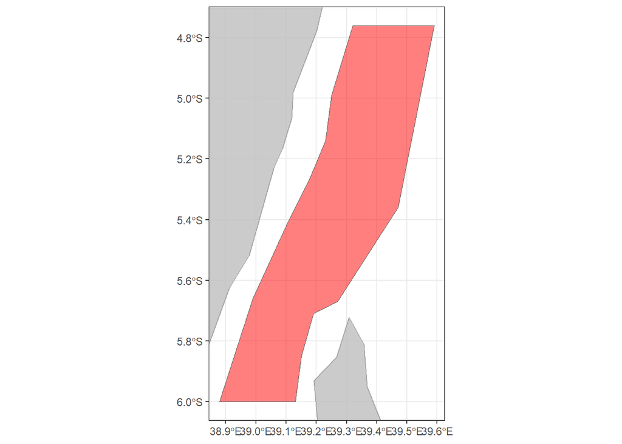

```r
worldmap <- ggplot2::map_data("world")
ptmp <- poly$tanzania$CoastalPolygons
lims <- st_bbox(ptmp)
xlim <- lims[c(1,3)]
ylim <- lims[c(2,4)]
map <- ggplot() +
  geom_map(data=worldmap, map=worldmap, aes(long, lat, group=group, map_id=region),
           fill="grey", colour="darkgrey", linewidth=0.5, alpha=0.8) +
  geom_sf(data=ptmp, fill="red", alpha=0.5) +
  coord_sf(xlim=xlim, ylim=ylim, expand=TRUE) +
  theme_bw() +
  theme(legend.position="none",
        axis.title = element_blank())
print(map)
```

# Links

- **PhytoFit on Github:** https://github.com/BIO-RSG/PhytoFit
- **Public PhytoFit host:** https://cioosatlantic.ca/phytofit/
- **OC-CCI links:** https://climate.esa.int/en/projects/ocean-colour/key-documents/, https://www.oceancolour.org/thredds/ncss/grid/CCI_ALL-v6.0-1km-DAILY/dataset.html
- **BIO remote sensing group (“SOPhyE”) website:** https://bio-rsg.github.io/